# Midterm - QBS 177

Spencer Bertsch  
Feb. 2022

Some helpful commands:  
* Insert a new code chunk: *Cmd+Option+I*  
* Run a code cell: *Cmd+Shift+Enter*  
* Preview the notebook HTML file: *Cmd+Shift+K*

**OPEN QUESTIONS:** Question (1) How do we do part (d)?

Question (3) Is it okay to use confint to find the confidence intervals? Is it alright that I looked up how to do that on Stack Overflow?

Question (3) - Shouldn’t **n** be 50 (the number of samples)? If I set it to 50 then my upper and lower bounds are way off, but if I set it to 21 (number of predictor variables) then they match perfectly. Hmmm…

### Imports

```r
library(glue)
library(qqman)
```

First we need to change our current working directory to the correct directory for Assignment 3

```r
setwd('/Users/spencerbertsch/Desktop/dev/phd_courses/MATH177/midterm')
getwd()
```

```
[1] "/Users/spencerbertsch/Desktop/dev/phd_courses/MATH177/midterm"
```

# Question 1

### Import the raw data

Here we load the data that contains all of the SNPs so we can see which are the top five SNPs that have the strongest association based on their p-values. We learned in assignment 4 and lab 5 that the lowest p-values designate the SNPs that have the strongest assosiation with a response variable.

```r
load('dbp.Rdata')
```

Before we can progress with question 1 (a), we need to do a few things. 1. We need to fill the NA values in our SNPs 2. We need to alter the data type of our SNPs from factor variables [2, 3, 4] to numeric variables [0, 1, 2].

```r
# lets isolate the columns we need for the problem
snp.data = dbp[,c("affection", "sex", "age", "rs1101", "rs1102", "rs1103", "rs1104", "rs1105", "rs1106", "rs1107", "rs1108", "rs1109", "rs1110", "rs1111", "rs1112", "rs1113", "rs1114", "rs1115", "rs1116", "rs1117", "rs1118", "rs1119", "rs1120")]

# convert all the SNP column to numeric and adjust them to the proper range
for (i in 1:20){
  snp.data[, (i+3)] <- as.numeric(snp.data[, (i+3)]) - 1
}

print('Summary after all the SNP variables were changed to numeric variables:')
```

```
[1] "Summary after all the SNP variables were changed to numeric variables:"
```

```r
summary(snp.data)
```

```
 affection sex          age            rs1101          rs1102           rs1103          rs1104
 0:300     1:329   Min.   :18.00   Min.   :0.000   Min.   :0.0000   Min.   :0.000   Min.   :0.000
 1:300     2:271   1st Qu.:38.00   1st Qu.:1.000   1st Qu.:0.0000   1st Qu.:0.000   1st Qu.:1.000
                   Median :55.00   Median :1.000   Median :0.0000   Median :1.000   Median :2.000
                   Mean   :55.49   Mean   :1.098   Mean   :0.5283   Mean   :0.935   Mean   :1.465
                   3rd Qu.:74.00   3rd Qu.:2.000   3rd Qu.:1.0000   3rd Qu.:1.000   3rd Qu.:2.000
                   Max.   :90.00   Max.   :2.000   Max.   :2.0000   Max.   :2.000   Max.   :2.000
                                                                                    NA's   :92
     rs1105          rs1106           rs1107          rs1108         rs1109          rs1110
 Min.   :0.000   Min.   :0.0000   Min.   :0.000   Min.   :0.00   Min.   :0.000   Min.   :0.000
 1st Qu.:1.000   1st Qu.:0.0000   1st Qu.:0.000   1st Qu.:0.00   1st Qu.:1.000   1st Qu.:1.000
 Median :1.000   Median :0.0000   Median :0.000   Median :1.00   Median :1.000   Median :1.000
 Mean   :1.088   Mean   :0.2989   Mean   :0.305   Mean   :0.96   Mean   :1.115   Mean   :1.088
 3rd Qu.:2.000   3rd Qu.:1.0000   3rd Qu.:1.000   3rd Qu.:1.00   3rd Qu.:2.000   3rd Qu.:2.000
 Max.   :2.000   Max.   :2.0000   Max.   :2.000   Max.   :2.00   Max.   :2.000   Max.   :2.000
                 NA's   :48
     rs1111         rs1112           rs1113           rs1114          rs1115          rs1116
 Min.   :0.00   Min.   :0.0000   Min.   :0.0000   Min.   :0.000   Min.   :0.000   Min.   :0.00
 1st Qu.:0.00   1st Qu.:0.0000   1st Qu.:0.0000   1st Qu.:0.000   1st Qu.:1.000   1st Qu.:2.00
 Median :1.00   Median :1.0000   Median :0.0000   Median :1.000   Median :2.000   Median :2.00
 Mean   :0.87   Mean   :0.5917   Mean   :0.5367   Mean   :0.835   Mean   :1.472   Mean   :1.84
 3rd Qu.:1.00   3rd Qu.:1.0000   3rd Qu.:1.0000   3rd Qu.:1.000   3rd Qu.:2.000   3rd Qu.:2.00
 Max.   :2.00   Max.   :2.0000   Max.   :2.0000   Max.   :2.000   Max.   :2.000   Max.   :2.00

     rs1117           rs1118           rs1119         rs1120
 Min.   :0.0000   Min.   :0.0000   Min.   :0.00   Min.   :0.000
 1st Qu.:0.0000   1st Qu.:0.0000   1st Qu.:1.00   1st Qu.:1.000
 Median :0.0000   Median :0.0000   Median :2.00   Median :1.000
 Mean   :0.3633   Mean   :0.5683   Mean   :1.63   Mean   :1.395
 3rd Qu.:1.0000   3rd Qu.:1.0000   3rd Qu.:2.00   3rd Qu.:2.000
 Max.   :2.0000   Max.   :2.0000   Max.   :2.00   Max.   :2.000
```

And indeed we can see that we were successful in converting all the SNPs to numeric dtypes.

# Question: Do we need to deal with NULLs here?

Here we examine the mean values of the columns. If the mean is NULL, that means there are NULL values in the dataframe that we need to fill with a method such as forward filling or mean value replacement.

```r
SNPs <- c("rs1101", "rs1102", "rs1103", "rs1104", "rs1105", "rs1106", "rs1107", "rs1108", "rs1109", "rs1110", "rs1111", "rs1112", "rs1113", "rs1114", "rs1115", "rs1116", "rs1117", "rs1118", "rs1119", "rs1120")
mu = colMeans(snp.data[, SNPs])
print(mu[0:10])
```

```
   rs1101    rs1102    rs1103    rs1104    rs1105    rs1106    rs1107    rs1108    rs1109    rs1110
1.0983333 0.5283333 0.9350000        NA 1.0883333        NA 0.3050000 0.9600000 1.1150000 1.0883333
```

And we can see that some of our SNP columns contain null values! So we can simply mean fill or forward fill these values and move on.

## TODO mean fill or forward fill the NAs

```r
# TODO fill NAs
```

### Question 1(a):

```r
pvalue <- 0

for (i in 1:20){

  # first we need to fit the logistic regression model on the SNP, adjusting for the age and sex of the patient
  result.adj <- glm(affection ~ sex + age + snp.data[,(i+3)], family=binomial("logit"), data=snp.data)

  # next we grab the corresponding p-value and store it outside the loop
  pvalue[i] <- summary(result.adj)$coef[4,4] # TODO <-- double check this p-value is right, we want the one corresponding to the SNP, correct? I think that's correct.
}

pvalue[0:10]
```

```
 [1] 0.89303925 0.96706492 0.46577256 0.05717227 0.80777910 0.73015069 0.17782240 0.29268567 0.74759244
[10] 0.53943123
```

```r
p_value_df <- data.frame(SNP = SNPs, p_value = pvalue)
p_value_df <- p_value_df[order(p_value_df$p_value, decreasing=FALSE), ]
head(p_value_df, 5)
```

|  | SNP | p_value |
| --- | --- | --- |
| 12 | rs1112 | 2.484971e-08 |
| 15 | rs1115 | 1.912459e-06 |
| 17 | rs1117 | 3.061879e-06 |
| 19 | rs1119 | 2.085480e-04 |
| 13 | rs1113 | 2.287019e-04 |

#### 1 (a) answer:

Here we can see that the SNPs with the strongest association (lowest p-values) are:  
1. rs1112  
2. rs1115  
3. rs1117  
4. rs1119  
5. rs1113

### Question 1(b):

Now that we trained our logistic regression model and got the associated p-values, we need to train a linear regression model and get the p-values there as well.

Let’s fill the NAs here: (OPTIONAL)

```r
# for (i in 1:20){
#   snp.data[is.na(snp.data[,(i+3)]), (i+3)] <- round(mean(snp.data[,(i+3)], na.rm = TRUE))
# }
# sum(is.na(snp.data))
```

Let’s also change the response variable from a factor to a numeric response! We need to do this for our linear regression model which predicts a continuous variable - not a factor variable.

```r
snp.data$affection <- as.numeric(snp.data$affection)
```

```r
pvalue <- 0

for (i in 1:20){

  # first we need to fit the linear regression model on the SNP, adjusting for the age and sex of the patient
  fit <- lm(affection ~ sex + age + snp.data[,(i+3)], data=snp.data)

  # next we grab the corresponding p-value and store it outside the loop
  pvalue[i] <- summary(fit)$coef[4,4]
}

pvalue[0:10]
```

```
 [1] 0.89334252 0.96747417 0.46718778 0.05699211 0.80871610 0.73109406 0.17866458 0.29389858 0.74831296
[10] 0.54053040
```

```r
p_value_df <- data.frame(SNP = SNPs, p_value = pvalue)
p_value_df <- p_value_df[order(p_value_df$p_value, decreasing=FALSE), ]
head(p_value_df, 10)
```

|  | SNP | p_value |
| --- | --- | --- |
| 12 | rs1112 | 8.557675e-09 |
| 15 | rs1115 | 1.085739e-06 |
| 17 | rs1117 | 1.779745e-06 |
| 19 | rs1119 | 1.650250e-04 |
| 13 | rs1113 | 1.922743e-04 |
| 18 | rs1118 | 2.697649e-04 |
| 20 | rs1120 | 9.288609e-04 |
| 4 | rs1104 | 5.699211e-02 |
| 7 | rs1107 | 1.786646e-01 |
| 14 | rs1114 | 1.946434e-01 |

#### 1 (b) answer:

Here we can see that the SNPs with the strongest association (lowest p-values) are:  
1. rs1112  
2. rs1115  
3. rs1117  
4. rs1119  
5. rs1113  
6. rs1118  
7. rs1120  
8. rs1104  
9. rs1107  
10. rs1114

### Question 1(c):

Before we begin with Question 1 (c), we need to convert the numerical variable back to a (binary) factor variable so that our logistic regression model can use it as the response variable.

```r
snp.data$affection <- as.factor(snp.data$affection)
```

We need a helper function that takes an r data frame and returns the coordinates of the smallest 10 values in the data frame in order.

```r
get_indices_smallest_values <- function(matrix) {
  # This helper function returns the [row, col] coordinates of the smallest values in the matrix in order
  # return type: list = [[ row1, col1], [row2, col2], ..., [row10, col10]]

  SNPs_1 <- 0
  SNPs_2 <- 0
  p_vals <- 0

  for (i in 1:10){

    # stores indexes of min value
    min = which(matrix == min(matrix), arr.ind = TRUE)
    print(paste("Minimum value: ", matrix[min]))

    # get the SNPs and the corresponding p-value
    index_1 <- as.integer(min[1,1])
    index_2 <- as.integer(min[1,2])
    snp1 <- SNPs[index_1]
    snp2 <- SNPs[index_2]
    p_val <- pvalue_mat[index_1, index_2]

    # save that data outside the loop
    SNPs_1[i] <- snp1
    SNPs_2[i] <- snp2
    p_vals[i] <- p_val

    # set the two values of the old smallest value to 1 and continue
    matrix[index_1, index_2] = 1
    matrix[index_2, index_1] = 1

  }

  # create a data frame out of the three lists that store the results
  df <- data.frame(A = SNPs_1, B = SNPs_2, C = p_vals)

  # return the data frame
  return(df)
}
```

Here we want to find the p-values for the strongest SNP-SNP interactions in our logistic regression model, still adjusting for age and sex of the subject.

```r
pvalue <- 0

# here we can initialize an empty matrix with 400 elements, each representing a p-value for the LR models we will train below
pvalue_mat <- setNames(data.frame(matrix(ncol = 20, nrow = 20)), SNPs)
rownames(pvalue_mat) <- SNPs


# in our outer for loop we iterate over the SNPs
for (i in 1:20){

  # Our inner loop also happens to iterate over the SNPs
  for (j in 1:20){

    # first we need to fit the logistic regression model on the SNP, adjusting for the age and sex of the patient
    result.adj <- glm(affection ~ sex + age + snp.data[,(i+3)]:snp.data[,(j+3)], family=binomial("logit"), data=snp.data)

    # next we grab the corresponding p-value and store it outside the loop
    pvalue_mat[i,j] <- summary(result.adj)$coef[4,4]
  }
}
```

And finally we can call our initial *get_indices_smallest_values* function to get the solution to the problem.

```r
df <- get_indices_smallest_values(matrix=pvalue_mat)
```

```
[1] "Minimum value:  1.56328211277827e-08" "Minimum value:  1.56328211277827e-08"
[1] "Minimum value:  1.04832286144208e-07" "Minimum value:  1.04832286144208e-07"
[1] "Minimum value:  1.27911114871315e-07" "Minimum value:  1.27911114871315e-07"
[1] "Minimum value:  1.59956762417977e-07" "Minimum value:  1.59956762417977e-07"
[1] "Minimum value:  8.22211690857412e-07"
[1] "Minimum value:  1.91463390270569e-06" "Minimum value:  1.91463390270569e-06"
[1] "Minimum value:  6.96572375594829e-06" "Minimum value:  6.96572375594829e-06"
[1] "Minimum value:  7.25590202725085e-06" "Minimum value:  7.25590202725085e-06"
[1] "Minimum value:  7.52698603224943e-06"
[1] "Minimum value:  9.27135853979422e-06" "Minimum value:  9.27135853979422e-06"
```

```r
head(df, 10)
```

|  | A | B | C |
| --- | --- | --- | --- |
| 1 | rs1112 | rs1109 | 1.563282e-08 |
| 2 | rs1112 | rs1110 | 1.048323e-07 |
| 3 | rs1116 | rs1112 | 1.279111e-07 |
| 4 | rs1112 | rs1105 | 1.599568e-07 |
| 5 | rs1112 | rs1112 | 8.222117e-07 |
| 6 | rs1112 | rs1103 | 1.914634e-06 |
| 7 | rs1117 | rs1109 | 6.965724e-06 |
| 8 | rs1117 | rs1110 | 7.255902e-06 |
| 9 | rs1115 | rs1115 | 7.526986e-06 |
| 10 | rs1120 | rs1112 | 9.271359e-06 |

#### 1 (c) answer:

So above we see the solution - the following are the top 10 SNP-SNP interactions with the strongest association:

1. [rs1112 rs1109]
2. [rs1112 rs1110]
3. [rs1116 rs1112]
4. [rs1112 rs1105]
5. [rs1112 rs1112]
6. [rs1112 rs1103]
7. [rs1117 rs1109]
8. [rs1117 rs1110]
9. [rs1115 rs1115]
10. [rs1120 rs1112]

We can also see the p-values corresponding to each pair in the above table.

### Question 1(d):

# Question 2

### Import the raw data

Here we load the fulldat data set.

```r
# load fulldat.txt
data <- read.table("fulldat.txt", header=F)
dim(data)
```

```
[1]  240 7401
```

```r
y <- data[,1]
x <- data[,3:7401]
```

We can see that we have only 240 observations, and 7401 variables! This is an interesting data set to use for supervised learning because the number of samples << the number of predictor variables which is not usually the case.

This is a perfect use case for Lasso regression! I’m glad to see such a great use case, I’ve never come across a data set that presents such a strong need for a model that forces the coefficients associated with unimportant predictors to zero. If I’m understanding the task of this problem correctly, we need to run a Lasso regression on the training set that’s generated from the data imported above. That Lasso model will no doubt drop many of our 7401 predictor variables by shrinking the weights for those variables down to zero. That model on its own could be very performant, but we’re to examine which of the predictor variables were chosen and isolate those, then train a step-wise regression model using **only** those predictors, and determine its performance using our test (holdout) data set.

I think the interesting part of this problem will be to compare the test performance of our initial Lasso model against the step-wise regression model that get’s trained on the genes (predictor variables, features) that are chosen consistently by Lasso over 100 trials. Which one will perform better? Let’s find out!

```r
# load the libraries we need for this problem
library(survival)
library(glmnet)

# we can set the seed here to get the same results for different random trials
set.seed(1)

# randomly divide the data in to training and testing
train <- sample(1:240,160,replace=FALSE)
test <- (1:240)[-train]

xtrain <- data[train,]
xtest <- data[test,]
```

We now have two data sets with the following dimensions: 1. xtrain: [160 x 7401] 1. xtest: [80 x 7401]

We now want to create an empty matrix filled with zeros so that we can populate the matrix later on. We can do that with the `matrix` command in r. We want out matrix to have 7399 rows and 100 columns.

```r
# create the coefout matrix with dimensions [7399 x 100] - initialize the matrix as a zero matrix
coefout <- matrix(0, 7399, 100)
```

Now that we have our coefout matrix initialized, we can run the loop that populates it.

```r
# loop 100 times, once for each of the trials
  for (i in 1:100){

    # create an array of integers that represent the sample IDs for 120 samples
    id <- sample(1:160, 120)

    # subset out training data to only include the samples chosen above
    data1 <- xtrain[id, ]

    # we can now isolate the column that contains the survival times (I assume years survived)
    surv <- data1[,1]

    # we now remove the non-predictor columns from our data set to isolate our predictors (genes)
    gene <- data1[, -(1:2)]
    x <- as.matrix(gene)

    # here we fit out lasso model
    fit2 <- glmnet(x,surv)

    # and here we perform a cross validation for our lasso model across many values for lambda.
    # just because we use Lasso here doesn't mean we know the best value for Lambda (that's what we find here)
    cvfit = cv.glmnet(x, surv)

    # some optimal plotting and data inspection - we don't want to do this at each iteration in the loop
    #plot(cvfit)
    #cvfit$lambda.min

    # here we find the coefficient values for our Lasso model. Remember this is Lasso, not Ridge! So many
    # of the values here should be zero
    coef.min = coef(cvfit, s = "lambda.min")[-1]

    # and lastly we can take the coefficients that are NOT zero and add them to the coefout outside of the loop
    coefout[,i] <- as.numeric(coef.min!=0)

    # we can use these two lines to find the coefficients that were non-zero
    #active.min = which(coef.min != 0)
    #index.min = coef.min[active.min]

}
```

```r
# stepwise code

K = 25

# coeffout1 gives us a vector of length 7399 in which we have a value for each predictor variable. The larger
# the value, the more times that predictor was chosen by Lasso during the 100 trials in the previous step.
coefout1 <- apply(coefout, 1, sum)

# here we use the value of K to only take the top (most important) predictors for use in the stepwise
# regression model
# we only keep values here if they were chosen by more than K trials of our Lasso model
active.min = which(coefout1>K)

# and lastly we can create a new training set called Xsub in which we use ONLY the predictor variables
# that made it through the cutoff above
Xsub <- x[,active.min]
```

We can now find and report the ‘best’ genes found by Lasso. We can do this by simply sorting our coefout1 vector and finding the corresponding indices for each of the max values.

```r
# create a data frame with an index storing values of Lasso coefficient values
best_genes <- data.frame(Gene_Number = c(1:length(coefout1)), Lasso_Selections = coefout1)

# we can now sort the dataframe based on the number of times each gene was chosen and display the best ones
best_genes <- best_genes[order(best_genes$Lasso_Selections, decreasing=TRUE), ]
head(best_genes, 10)
```

|  | Gene_Number | Lasso_Selections |
| --- | --- | --- |
| 4131 | 4131 | 75 |
| 1020 | 1020 | 67 |
| 4762 | 4762 | 61 |
| 5777 | 5777 | 55 |
| 3191 | 3191 | 53 |
| 428 | 428 | 46 |
| 1456 | 1456 | 45 |
| 1358 | 1358 | 42 |
| 6956 | 6956 | 35 |
| 1188 | 1188 | 33 |

#### Question 2 answer (part I): Report genes consistently chosen by Lasso

Some of the genes that are consistently chosen by lasso are:  
1. 4131  
2. 1020  
3. 4762  
4. 5777  
5. 3191

Even more of the genes that were consistently chosen can be seen in the above table. Each of the above genes is also displayed alongside the number of times it was chosen by the Lasso model. If a grader wants to see more genes, then feel free to take the head showing more of the top records above.

#### Train our stepwise regression

And finally we get to jump in and write the rest of the code. Here we want to just run a stepwise regression using the `Xsub` data set created above.

Perform a rewrite using the code from Lab5 (steps 1-4)

```r
data <- read.table("fulldat.txt", header=F)
data[1:3,1:10]
```

|  | V1 | V2 | V3 | V4 | V5 | V6 | V7 | V8 | V9 | V10 |
| --- | --- | --- | --- | --- | --- | --- | --- | --- | --- | --- |
| 1 | 4.0 | 0 | -0.2210 | -0.1786 | -0.05025 | -0.1922 | -0.2944 | 0.7544000 | 1.0030 | 0.2628 |
| 2 | 4.9 | 0 | -0.1946 | -0.2238 | -0.12600 | -0.1614 | -0.1994 | -0.3474625 | 0.2532 | 0.9026 |
| 3 | 5.6 | 0 | -0.3179 | -0.1585 | -0.48560 | -0.3483 | -0.4490 | -0.1726000 | 0.2333 | 1.2680 |

```r
y <- data[,1]
# include all the predictors in x
x <- data[,3:(dim(data)[2])]
# now only include the predictors that were chosen by Lasso
x <- x[,active.min]

workingD <- data.frame(cbind(y,x))
```

```r
set.seed(1)

# randomly divide the data in to training and testing
train <- sample(1:240,160,replace=FALSE)
test <- (1:240)[-train]
```

```r
fit1 <- lm(y ~ ., workingD, subset=train)
fit2 <- lm(y ~ 1, workingD, subset=train)
step1 <- step(fit1,direction="both")  #both direction
```

```
Start:  AIC=357.85
y ~ V430 + V1022 + V1101 + V1190 + V1360 + V1458 + V1841 + V1988 +
    V3193 + V3397 + V4133 + V4764 + V5779 + V6012 + V6671 + V6958 +
    V7324

        Df Sum of Sq    RSS    AIC
- V1458  1     2.549 1198.5 356.19
- V5779  1     3.577 1199.5 356.32
- V1988  1    12.726 1208.7 357.54
<none>               1196.0 357.85
- V7324  1    19.797 1215.8 358.47
- V1841  1    19.881 1215.8 358.48
- V1360  1    24.813 1220.8 359.13
- V1101  1    33.422 1229.4 360.26
- V1190  1    42.849 1238.8 361.48
- V4764  1    45.390 1241.4 361.81
- V6958  1    53.650 1249.6 362.87
- V1022  1    54.937 1250.9 363.03
- V3193  1    58.532 1254.5 363.49
- V3397  1    60.952 1256.9 363.80
- V6012  1    86.543 1282.5 367.02
- V4133  1    97.617 1293.6 368.40
- V6671  1   108.094 1304.1 369.69
- V430   1   128.259 1324.2 372.15

Step:  AIC=356.19
y ~ V430 + V1022 + V1101 + V1190 + V1360 + V1841 + V1988 + V3193 +
    V3397 + V4133 + V4764 + V5779 + V6012 + V6671 + V6958 + V7324

        Df Sum of Sq    RSS    AIC
- V5779  1     3.443 1202.0 354.65
<none>               1198.5 356.19
- V1988  1    16.913 1215.4 356.43
- V7324  1    21.922 1220.4 357.09
- V1841  1    22.730 1221.2 357.19
- V1360  1    23.829 1222.3 357.34
+ V1458  1     2.549 1196.0 357.85
- V1101  1    34.090 1232.6 358.67
- V1190  1    41.874 1240.4 359.68
- V4764  1    50.240 1248.8 360.76
```

[output cut: 17 more lines]

```
- V1841  1    27.800 1229.8 356.30
+ V1458  1     2.415 1199.5 356.32
- V7324  1    28.162 1230.1 356.35
- V1360  1    28.708 1230.7 356.42
- V1101  1    34.126 1236.1 357.13
- V1190  1    50.461 1252.4 359.23
- V6958  1    53.428 1255.4 359.60
- V1022  1    53.596 1255.6 359.63
- V4764  1    57.995 1260.0 360.19
- V3397  1    65.226 1267.2 361.10
- V6012  1    84.058 1286.0 363.46
- V3193  1    87.594 1289.6 363.90
- V4133  1    97.906 1299.9 365.18
- V6671  1   107.501 1309.5 366.35
- V430   1   135.801 1337.8 369.77
```

```r
step2 <- step(fit1,direction="backward") #backward
```

```
Start:  AIC=357.85
y ~ V430 + V1022 + V1101 + V1190 + V1360 + V1458 + V1841 + V1988 +
    V3193 + V3397 + V4133 + V4764 + V5779 + V6012 + V6671 + V6958 +
    V7324

        Df Sum of Sq    RSS    AIC
- V1458  1     2.549 1198.5 356.19
- V5779  1     3.577 1199.5 356.32
- V1988  1    12.726 1208.7 357.54
<none>               1196.0 357.85
- V7324  1    19.797 1215.8 358.47
- V1841  1    19.881 1215.8 358.48
- V1360  1    24.813 1220.8 359.13
- V1101  1    33.422 1229.4 360.26
- V1190  1    42.849 1238.8 361.48
- V4764  1    45.390 1241.4 361.81
- V6958  1    53.650 1249.6 362.87
- V1022  1    54.937 1250.9 363.03
- V3193  1    58.532 1254.5 363.49
- V3397  1    60.952 1256.9 363.80
- V6012  1    86.543 1282.5 367.02
- V4133  1    97.617 1293.6 368.40
- V6671  1   108.094 1304.1 369.69
- V430   1   128.259 1324.2 372.15

Step:  AIC=356.19
y ~ V430 + V1022 + V1101 + V1190 + V1360 + V1841 + V1988 + V3193 +
    V3397 + V4133 + V4764 + V5779 + V6012 + V6671 + V6958 + V7324

        Df Sum of Sq    RSS    AIC
- V5779  1     3.443 1202.0 354.65
<none>               1198.5 356.19
- V1988  1    16.913 1215.4 356.43
- V7324  1    21.922 1220.4 357.09
- V1841  1    22.730 1221.2 357.19
- V1360  1    23.829 1222.3 357.34
- V1101  1    34.090 1232.6 358.67
- V1190  1    41.874 1240.4 359.68
- V4764  1    50.240 1248.8 360.76
- V1022  1    53.538 1252.1 361.18
```

[output cut: 14 more lines]

```
- V1988  1    20.195 1222.2 355.31
- V1841  1    27.800 1229.8 356.30
- V7324  1    28.162 1230.1 356.35
- V1360  1    28.708 1230.7 356.42
- V1101  1    34.126 1236.1 357.13
- V1190  1    50.461 1252.4 359.23
- V6958  1    53.428 1255.4 359.60
- V1022  1    53.596 1255.6 359.63
- V4764  1    57.995 1260.0 360.19
- V3397  1    65.226 1267.2 361.10
- V6012  1    84.058 1286.0 363.46
- V3193  1    87.594 1289.6 363.90
- V4133  1    97.906 1299.9 365.18
- V6671  1   107.501 1309.5 366.35
- V430   1   135.801 1337.8 369.77
```

```r
step3 <- step(fit2,direction="forward",scope=list(upper=fit1,lower=fit2))  #forward
```

```
Start:  AIC=468.58
y ~ 1

        Df Sum of Sq    RSS    AIC
+ V4133  1    365.35 2589.8 449.46
+ V5779  1    359.58 2595.5 449.82
+ V1190  1    285.50 2669.6 454.32
+ V1022  1    280.97 2674.2 454.59
+ V1458  1    259.16 2696.0 455.89
+ V3193  1    250.47 2704.7 456.41
+ V4764  1    238.23 2716.9 457.13
+ V1841  1    231.03 2724.1 457.55
+ V7324  1    225.14 2730.0 457.90
+ V1988  1    209.32 2745.8 458.82
+ V1101  1    204.65 2750.5 459.10
+ V1360  1    189.97 2765.1 459.95
+ V430   1    153.22 2801.9 462.06
+ V6958  1    147.41 2807.7 462.39
+ V6012  1    139.46 2815.7 462.84
+ V3397  1    119.40 2835.7 463.98
+ V6671  1     84.36 2870.8 465.95
<none>               2955.1 468.58

Step:  AIC=449.46
y ~ V4133

        Df Sum of Sq    RSS    AIC
+ V5779  1   240.775 2349.0 435.85
+ V1022  1   225.734 2364.0 436.87
+ V1458  1   198.547 2391.2 438.70
+ V4764  1   195.740 2394.0 438.89
+ V3193  1   194.708 2395.1 438.96
+ V1101  1   180.133 2409.6 439.93
+ V430   1   167.334 2422.4 440.78
+ V1360  1   166.982 2422.8 440.80
+ V1841  1   165.603 2424.2 440.89
+ V6958  1   154.282 2435.5 441.64
+ V7324  1   144.621 2445.2 442.27
+ V1190  1   139.828 2449.9 442.58
+ V6012  1   113.735 2476.0 444.28
```

[output cut: 207 more lines]

```
y ~ V4133 + V5779 + V1022 + V4764 + V1101 + V430 + V3193 + V6012 +
    V6671 + V3397 + V6958 + V1841 + V1190 + V1360 + V7324

        Df Sum of Sq    RSS    AIC
+ V1988  1   16.9128 1198.5 356.19
<none>               1215.4 356.43
+ V1458  1    6.7353 1208.7 357.54

Step:  AIC=356.19
y ~ V4133 + V5779 + V1022 + V4764 + V1101 + V430 + V3193 + V6012 +
    V6671 + V3397 + V6958 + V1841 + V1190 + V1360 + V7324 + V1988

        Df Sum of Sq    RSS    AIC
<none>               1198.5 356.19
+ V1458  1    2.5489 1196.0 357.85
```

```r
summary(step1)
```

```
Call:
lm(formula = y ~ V430 + V1022 + V1101 + V1190 + V1360 + V1841 +
    V1988 + V3193 + V3397 + V4133 + V4764 + V6012 + V6671 + V6958 +
    V7324, data = workingD, subset = train)

Residuals:
   Min     1Q Median     3Q    Max
-6.607 -1.758 -0.168  1.588  9.007

Coefficients:
            Estimate Std. Error t value Pr(>|t|)
(Intercept)   3.5804     0.2492  14.367  < 2e-16 ***
V430         -1.3445     0.3333  -4.034 8.88e-05 ***
V1022        -0.7871     0.3106  -2.534 0.012348 *
V1101        -1.3183     0.6520  -2.022 0.045031 *
V1190         0.7198     0.2928   2.459 0.015128 *
V1360        -1.0013     0.5399  -1.855 0.065707 .
V1841        -0.9419     0.5161  -1.825 0.070077 .
V1988        -0.7845     0.5044  -1.555 0.122036
V3193        -1.4259     0.4402  -3.239 0.001487 **
V3397         0.4900     0.1753   2.795 0.005891 **
V4133         0.3916     0.1143   3.425 0.000802 ***
V4764         1.3564     0.5146   2.636 0.009311 **
V6012         2.0516     0.6465   3.173 0.001842 **
V6671         1.8060     0.5032   3.589 0.000455 ***
V6958        -0.9753     0.3855  -2.530 0.012482 *
V7324        -1.0715     0.5833  -1.837 0.068295 .
---
Signif. codes:  0 ‘***’ 0.001 ‘**’ 0.01 ‘*’ 0.05 ‘.’ 0.1 ‘ ’ 1

Residual standard error: 2.889 on 144 degrees of freedom
Multiple R-squared:  0.5933,    Adjusted R-squared:  0.5509
F-statistic:    14 on 15 and 144 DF,  p-value: < 2.2e-16
```

```r
summary(step2)
```

```
Call:
lm(formula = y ~ V430 + V1022 + V1101 + V1190 + V1360 + V1841 +
    V1988 + V3193 + V3397 + V4133 + V4764 + V6012 + V6671 + V6958 +
    V7324, data = workingD, subset = train)

Residuals:
   Min     1Q Median     3Q    Max
-6.607 -1.758 -0.168  1.588  9.007

Coefficients:
            Estimate Std. Error t value Pr(>|t|)
(Intercept)   3.5804     0.2492  14.367  < 2e-16 ***
V430         -1.3445     0.3333  -4.034 8.88e-05 ***
V1022        -0.7871     0.3106  -2.534 0.012348 *
V1101        -1.3183     0.6520  -2.022 0.045031 *
V1190         0.7198     0.2928   2.459 0.015128 *
V1360        -1.0013     0.5399  -1.855 0.065707 .
V1841        -0.9419     0.5161  -1.825 0.070077 .
V1988        -0.7845     0.5044  -1.555 0.122036
V3193        -1.4259     0.4402  -3.239 0.001487 **
V3397         0.4900     0.1753   2.795 0.005891 **
V4133         0.3916     0.1143   3.425 0.000802 ***
V4764         1.3564     0.5146   2.636 0.009311 **
V6012         2.0516     0.6465   3.173 0.001842 **
V6671         1.8060     0.5032   3.589 0.000455 ***
V6958        -0.9753     0.3855  -2.530 0.012482 *
V7324        -1.0715     0.5833  -1.837 0.068295 .
---
Signif. codes:  0 ‘***’ 0.001 ‘**’ 0.01 ‘*’ 0.05 ‘.’ 0.1 ‘ ’ 1

Residual standard error: 2.889 on 144 degrees of freedom
Multiple R-squared:  0.5933,    Adjusted R-squared:  0.5509
F-statistic:    14 on 15 and 144 DF,  p-value: < 2.2e-16
```

```r
summary(step3)
```

```
Call:
lm(formula = y ~ V4133 + V5779 + V1022 + V4764 + V1101 + V430 +
    V3193 + V6012 + V6671 + V3397 + V6958 + V1841 + V1190 + V1360 +
    V7324 + V1988, data = workingD, subset = train)

Residuals:
    Min      1Q  Median      3Q     Max
-6.5045 -1.7594 -0.1256  1.5135  8.8980

Coefficients:
            Estimate Std. Error t value Pr(>|t|)
(Intercept)   3.5917     0.2504  14.347  < 2e-16 ***
V4133         0.3903     0.1146   3.406 0.000856 ***
V5779        -0.4706     0.7342  -0.641 0.522599
V1022        -0.7867     0.3113  -2.527 0.012578 *
V4764         1.2887     0.5264   2.448 0.015562 *
V1101        -1.3176     0.6533  -2.017 0.045590 *
V430         -1.3209     0.3361  -3.930 0.000132 ***
V3193        -1.4380     0.4415  -3.257 0.001406 **
V6012         2.0670     0.6483   3.189 0.001757 **
V6671         1.8339     0.5061   3.623 0.000403 ***
V3397         0.4873     0.1757   2.774 0.006283 **
V6958        -0.9833     0.3865  -2.544 0.012019 *
V1841        -0.8710     0.5289  -1.647 0.101790
V1190         0.6745     0.3018   2.235 0.026954 *
V1360        -0.9309     0.5521  -1.686 0.093945 .
V7324        -0.9757     0.6033  -1.617 0.108023
V1988        -0.7286     0.5129  -1.421 0.157627
---
Signif. codes:  0 ‘***’ 0.001 ‘**’ 0.01 ‘*’ 0.05 ‘.’ 0.1 ‘ ’ 1

Residual standard error: 2.895 on 143 degrees of freedom
Multiple R-squared:  0.5944,    Adjusted R-squared:  0.549
F-statistic:  13.1 on 16 and 143 DF,  p-value: < 2.2e-16
```

```r
tempname <- names(step1$coef)
colname <- match(tempname[-1], names(x)) #Model identification
predscore <- as.matrix(x[test,colname])%*%step1$coef[-1] #testing score
summary(lm(y[test]~predscore))
```

```
Call:
lm(formula = y[test] ~ predscore)

Residuals:
   Min     1Q Median     3Q    Max
-6.091 -3.504 -1.645  2.476 12.977

Coefficients:
            Estimate Std. Error t value Pr(>|t|)
(Intercept)   4.5351     0.5163   8.784 2.83e-13 ***
predscore     0.3459     0.1883   1.837     0.07 .
---
Signif. codes:  0 ‘***’ 0.001 ‘**’ 0.01 ‘*’ 0.05 ‘.’ 0.1 ‘ ’ 1

Residual standard error: 4.492 on 78 degrees of freedom
Multiple R-squared:  0.04147,   Adjusted R-squared:  0.02918
F-statistic: 3.375 on 1 and 78 DF,  p-value: 0.07002
```

```r
p_val <- summary(lm(y[test]~predscore))$coef[2,4]
print(p_val)
```

```
[1] 0.07001617
```

#### Question 2 answer (part II):

We can see that, for a K value of **K=25**, we get a p_value of **0.07001617** in the resulting model. We can see from the p-value that the results are not significant, so the model that performed well on the training set did not perform quite as well on the testing set. This makes sense because we’re trying to use people’s genes to predict how long they have to live, which is an incredibly difficult task. It would be surprising if our stepwise regression model was able to perform well, so it’s not surprising to see an adjusted r-squared of 0.02918.

# Question 3

### Import the raw data

Here we load the data that contains the data that will be used for linear regression models. This Rdata contains a response vairbale **y** in addition to the **reduceddat** in which each row will become a predictor.

```r
load('lab2.Rdata')
```

Our job here is to first use a loop to iterate through each of the rows in the **reduceddat** matrix and use each row as a predictor for the response variabe **yy**. Then we need to report the regression slope and the 95% confidence interval for each iteration.

First we can prepare our data for regression:

```r
# here we need to grab the actual vector of responses from the data frame
y <- yy[, 2]

# and we can define the number of rows we will iterate over
row_count <- length(reducedat[,1])
```

#### Question 3 (a)

```r
slope <- 0
CI_2.5 <- 0
CI_97.5 <- 0

for (i in 1:row_count){

  coeff <- 1.96

  # first we need to fit the linear regression model on the current row of the reducedat matrix
  fit <- lm(y ~ reducedat[i,])

  # next we grab the corresponding slope and store it outside the loop
  current_slope <- summary(fit)$coef[2,1]
  slope[i] <- current_slope

  # we can now calculate the 95% confidence interval manually by adding and subtracting two times
  # the standard error to get the 2.5% lower bound and the 97.5% upper bound respectively.
  std_error <- summary(fit)$coef[2,2]

  # here we can calculate the 95% confidence interval
  CI_2.5[i] <- current_slope - (coeff*std_error)
  CI_97.5[i] <- current_slope + (coeff*std_error)
}

slope[0:10]
```

```
 [1]   98.39391   96.18040   95.21852   96.62498 -122.74232 -122.74232 -119.36548 -120.98765   42.66625 -118.94231
```

And now all we need to do is turn these vectors into a dataframe and present our results!

```r
results <- data.frame(slope, CI_2.5, CI_97.5)
results
```

| slope | CI_2.5 | CI_97.5 |
| --- | --- | --- |
| 98.39391 | 74.40595 | 122.38187 |
| 96.18040 | 70.66804 | 121.69276 |
| 95.21852 | 69.61197 | 120.82506 |
| 96.62498 | 70.34110 | 122.90887 |
| -122.74232 | -158.95871 | -86.52593 |
| -122.74232 | -158.95871 | -86.52593 |
| -119.36548 | -155.18945 | -83.54151 |
| -120.98765 | -157.42040 | -84.55490 |
| 42.66625 | 29.75418 | 55.57833 |
| -118.94231 | -155.30020 | -82.58443 |

[output cut: 40 more lines]

#### Question 3 answer (a):

See the above table for the results. That table contains the slopes, and the upper and lower bounds on the 95% confidence interval for each of the 50 regressions that were performed.

#### Question 3 (b)

In this part of the question, we want to re-calculate the upper and lower bounds on the 95% confidence interval, but instead of calculating them inside each iteration of the modeling loop, we want to use the summary statistics about our data in addition to the estimated slopes to find the upper and lower bounds. This should theoretically be much faster and give us very similar results to the upper and lower bounds on the 95% confidence interval found above.

- **Define r^2**

Part of this equation retuires **r** which I’m assuming is the correlation coefficient. We’ve seen this before in this class! There’s a native `r` function that can give us the correlation coefficient, so we can calculate all of the **r** values here:

```r
# do we need to do this without a loop? I'm not sure how I could do that...
r <- 0
std_x <- 0
for (i in 1:50){
  r[i] <- cor(y, reducedat[i,], method = "pearson")
  std_x[i] <- sd(reducedat[i,])
}
r_squared <- r^2
```

- **Define n**

Here we can define the sample size: **n** Note that unlike **r^2**, **n** is a scalar, not a vector.

```r
n <- 21 # length(reducedat[,1])
```

- **Define sample standard deviation**

Here we can define the sample standard deviation and square it to get Sx^2:

```r
# do we need to do this without a loop? I'm not sure how I could do that...
std_x <- 0
for (i in 1:50){
  std_x[i] <- sd(reducedat[i,])
}
std_x_squared <- std_x^2
```

- **Define standard deviation of the response**

Here we can define the standard deviation of our response variable **y**and square it to get Sy^2:

```r
std_y <- sd(y)
std_y_squared <- std_y^2
```

- **Define slopes (b)**

We already calculated the slopes above, so lets just define a new variable called **b** that represents our 50 slopes:

```r
b <- results$slope
```

And finally we have all the components we need to calculate the upper and lower bounds on the confidence interval! Let’s do that now:

```r
# define the numerator
num <- (1 - r_squared) * std_y_squared

# define the denominator
denom <- (n - 2) * std_x_squared

bound_level <- 1.96*(sqrt(num/denom))

CI_2.5_new <- b - bound_level
CI_97.5_new <- b + bound_level

results_new <- data.frame(b, CI_2.5_new, CI_97.5_new)
results_new
```

| b | CI_2.5_new | CI_97.5_new |
| --- | --- | --- |
| 98.39391 | 74.40595 | 122.38187 |
| 96.18040 | 70.66804 | 121.69276 |
| 95.21852 | 69.61197 | 120.82506 |
| 96.62498 | 70.34110 | 122.90887 |
| -122.74232 | -158.95871 | -86.52593 |
| -122.74232 | -158.95871 | -86.52593 |
| -119.36548 | -155.18945 | -83.54151 |
| -120.98765 | -157.42040 | -84.55490 |
| 42.66625 | 29.75418 | 55.57833 |
| -118.94231 | -155.30020 | -82.58443 |

[output cut: 40 more lines]

Now we can see how well we did! Lets find the difference between our old upper and lower bounds, and the new upper and lower bounds.

```r
sum(results$CI_2.5 - results_new$CI_2.5_new)
```

```
[1] -1.12621e-12
```

We see here that the lower bounds match up almost perfectly.

```r
sum(results$CI_97.5 - results_new$CI_97.5_new)
```

```
[1] 9.30811e-13
```

We see here that the upper bounds match up almost perfectly as well. In addition, we can plot the lower and upper bounds against eachother to make sure we get a straight line.

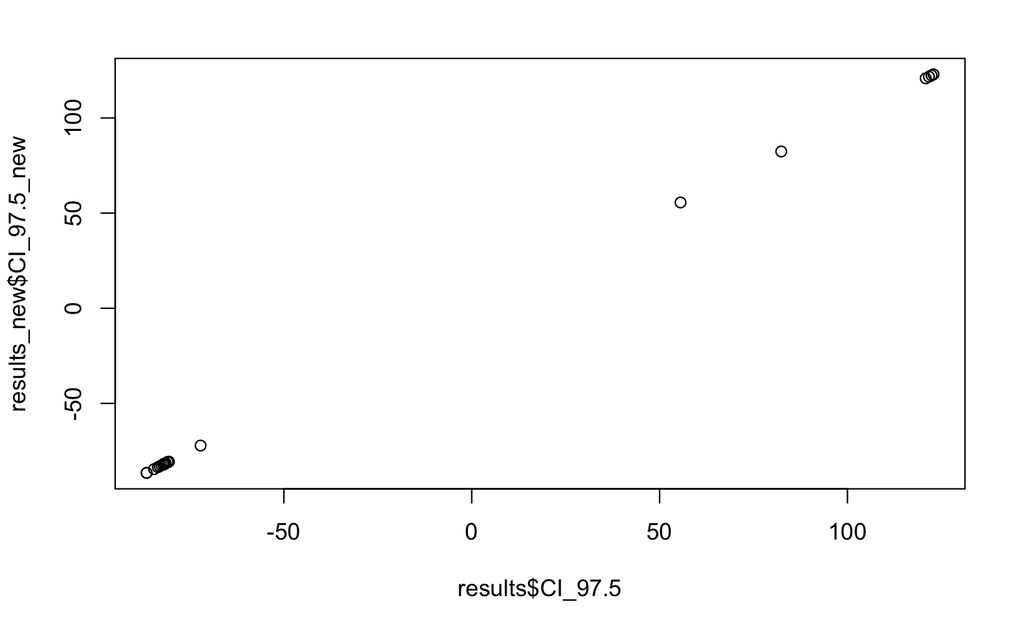

```r
plot(results$CI_97.5, results_new$CI_97.5_new)
```

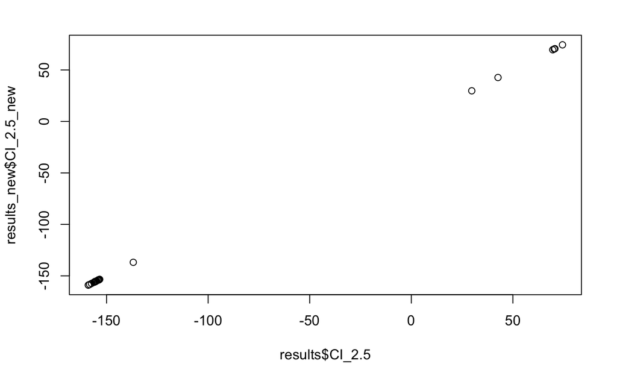

```r
plot(results$CI_2.5, results_new$CI_2.5_new)
```

And indeed we do! Great, all of this means that the 95% confidence interval we found in problem 3(a) matches the one we calculated in problem 3(b).

### Question 3 (c)

Please see the attached Excel sheet for the solution to 3(c).